# Week 6 Lecture

## Introduction to Matplotlib

`Matplotlib` is the most widely used library for **creating static, interactive, and animated visualizations in Python**. It offers extensive functionality to create a wide variety of plots, from simple `line plots` to complex visualizations like `heatmaps` and `3D plots`.

### Why Use `Matplotlib`?

- **Simplicity and Flexibility**: `Matplotlib` provides a simple interface for quickly generating basic plots, while also offering extensive control over the appearance and behavior of `plots`. **You can customize every aspect of your figures**, from `colors` and `markers` to `axes` and `labels`.
- **Wide Range of Plot Types**: Whether you need basic `line plots`, `bar charts`, `histograms`, `scatter plots`, or more specialized visualizations like `pie charts`, Matplotlib can handle it all. It also supports more advanced features such as `subplots` and `multiple axes`.
- **Integration with Other Libraries**: `Matplotlib` integrates well with other libraries such as `Pandas` and `NumPy`, making it easy to plot data directly from these popular data science tools. It’s commonly used alongside `Seaborn`, **a higher-level statistical visualization library that builds on `Matplotlib`** for more aesthetically pleasing plots.
- **Publication-Quality Figures**: One of the most powerful features of Matplotlib is its ability to generate high-quality, publication-ready figures in various formats (e.g., `PNG`, `PDF`, `SVG`).

## Setting up Matplotlib

To begin with, let's ensure that we have matplotlib installed and set up:

```
!pip install matplotlib
```

```python
!pip install matplotlib
```

!pip install matplotlib

```python
import matplotlib.pyplot as plt
import pandas as pd

plt.rcParams['figure.figsize'] = [10, 5] # Set the size of the plot
```

import matplotlib.pyplot as plt import pandas as pd plt.rcParams['figure.figsize'] = [10, 5] # Set the size of the plot

## Basic Plot and Workflow

Every plot in `Matplotlib` follows a standard structure:

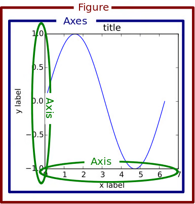

1. **Figure**: The entire image or plot, which can contain multiple subplots.
2. **Axis**: Represents the horizontal (x) and vertical (y) scales on the graph, including `ticks` and `labels`.
3. **Plot Elements**: These include `lines`, `markers`, `bars`, etc., that **represent data points on the `axes`**.